# L09 Themes

Data Visualization (STAT 302)

Martha Eichlersmith

2020-05-10

```r
library(knitr)
opts_chunk$set(dpi = 300)
```

## Overview

The goal of this lab is to play around with the theme options in `ggplot2`

## Datasets

We’ll be using the `cdc.txt` datasets.

```r
# Load package(s)
library(tidyverse)
library(gridExtra)

#import fonts - only once, take ~5min
#font_import()

#load fonts
extrafont::loadfonts(device = "win")

# Read in the cdc dataset
cdc <- read_delim(file = "data/cdc.txt", delim = "|") %>%
  mutate(genhlth = factor(genhlth,
    levels = c("excellent", "very good", "good", "fair", "poor"),
    labels = c("Excellent", "Very Good", "Good", "Fair", "Poor")
  ))

# Set seed
set.seed(8221984)

# Selecting a random subset of size 100
cdc_small <- cdc %>% sample_n(100)
```

## Exercises

### Exercise 1

Use the `cdc_small` dataset to explore several pre-set `ggthemes`. The code below constructs the familiar scatterplot of `weight` by `height` and stores it in `plot_01`. Display `plot_01` to observe the default theme. **Explore/apply, and display at least 7 other pre-set themes** from the `ggplot2` or `ggthemes` package. Don’t worry about making adjustments to the figures under the new themes. Just get a sense of what the themes are doing to the original figure `plot_01`.

There should be at least 8 plots for this task. `temp1` is pictured below.

```r
# Building plot
base <- ggplot(data = cdc_small, aes(x = height, y = weight)) +
  geom_point(size = 3, aes(shape = genhlth, color = genhlth)) +
  scale_y_continuous(
    name = "Weight in Pounds",
    limits = c(100, 300),
    breaks = seq(100, 350, 25),
    trans = "log10",
    labels = scales::unit_format(unit = "lbs")
  ) +
  scale_x_continuous(
    name = "Height in Inches",
    limits = c(55, 80),
    breaks = seq(55, 80, 5),
    labels = scales::unit_format(unit = "in", accuracy = 1)
  ) +
  scale_shape_manual(
    name = "General\nHealth?",
    labels = c("Excellent", "Very Good", "Good", "Fair", "Poor"),
    values = c(17, 19, 15, 9, 4)
  ) +
  scale_color_brewer(
    name = "General\nHealth?",
    labels = c("Excellent", "Very Good", "Good", "Fair", "Poor"),
    palette = "Set1"
  ) +
  labs(subtitle = "CDC BRFSS: Weight by Height")

legend_theme <- function(...){
  theme(
    legend.position = c(1, 0),
    legend.justification = c(1, 0)
  )
}
```

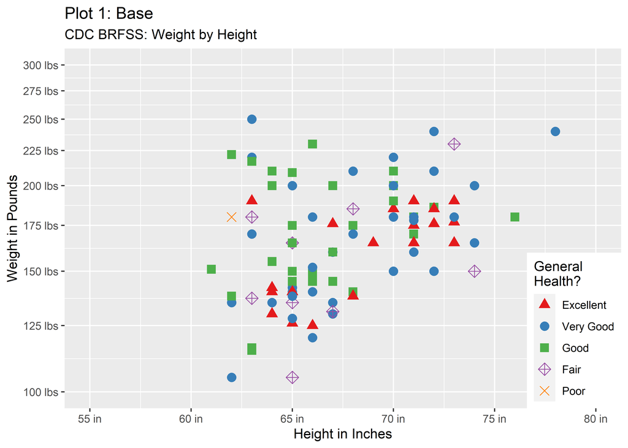

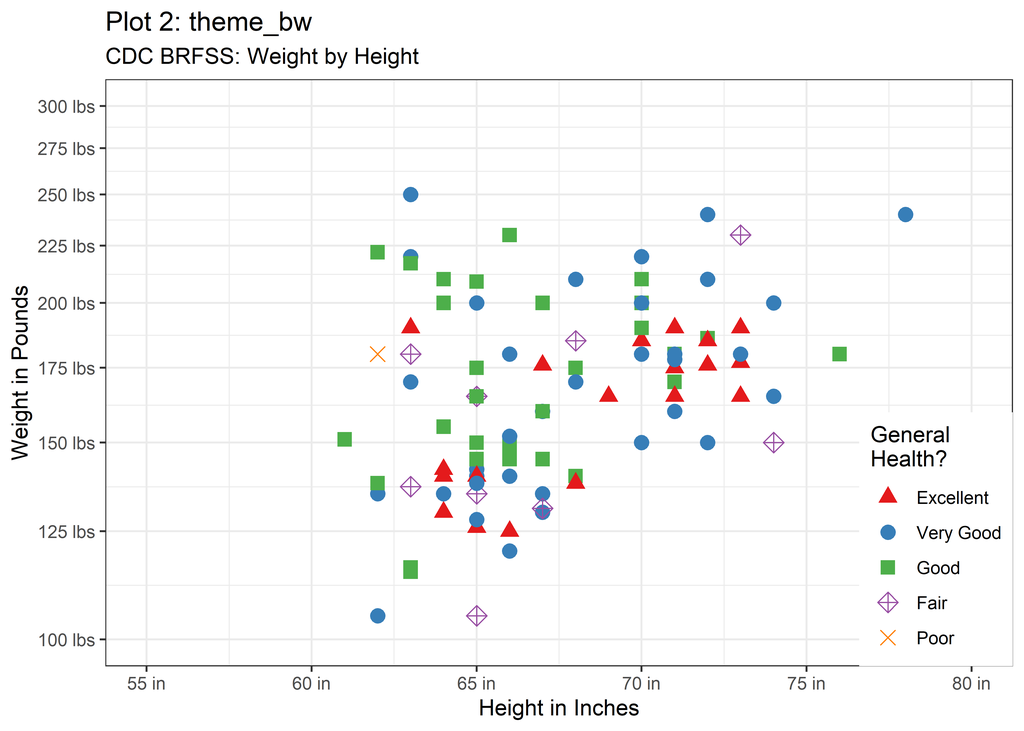

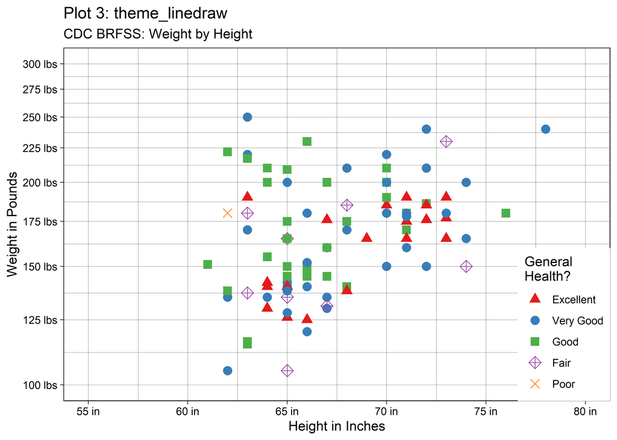

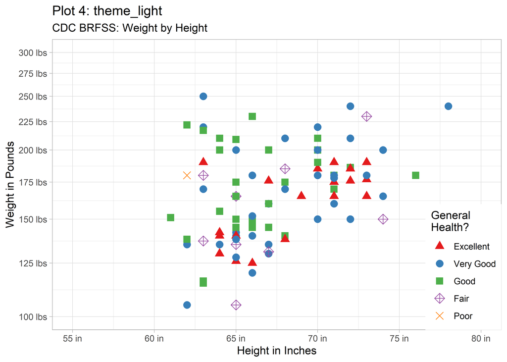

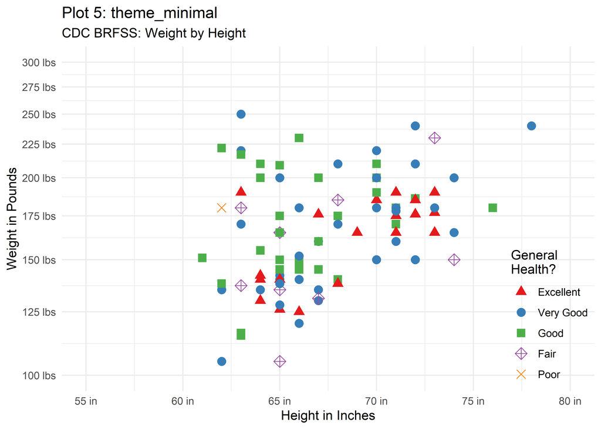

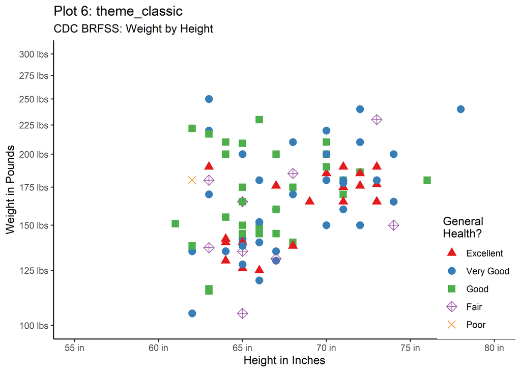

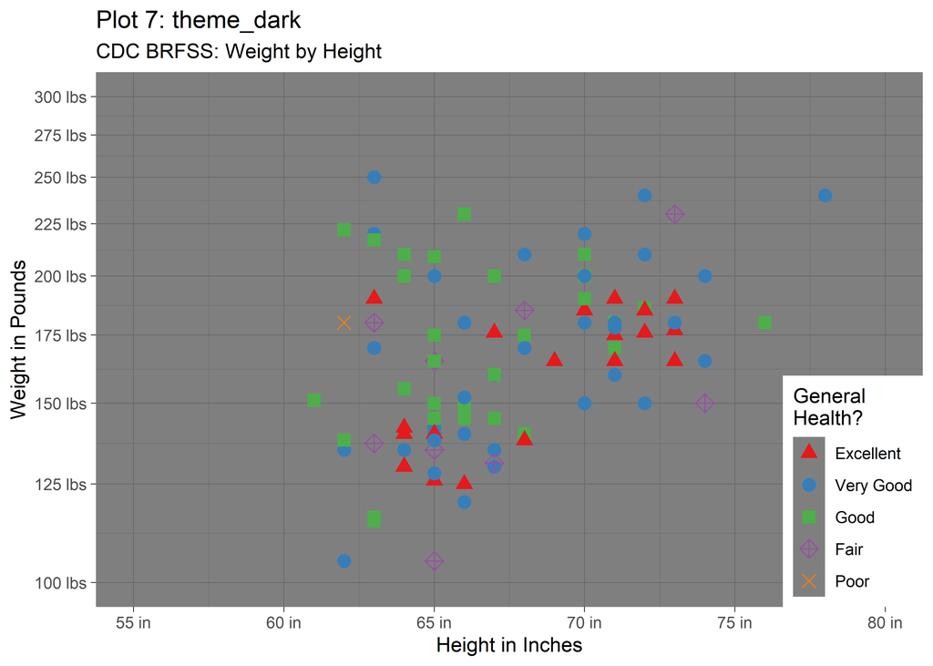

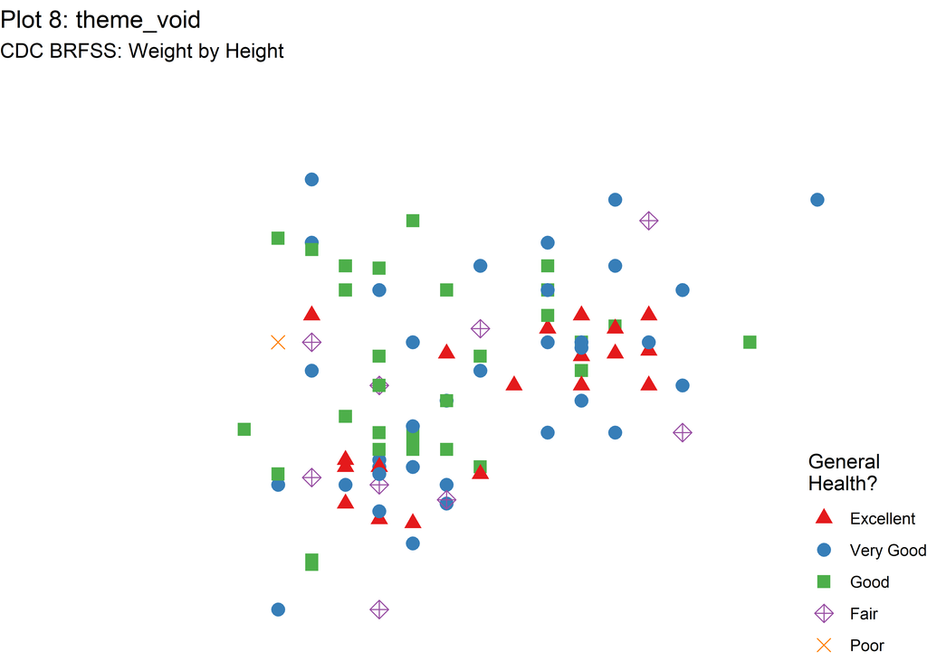

```r
#out.width = '50%'
#fig.show='hold' - print at the end of code
p1 <- base + ggtitle("Plot 1: Base") + legend_theme()
p1

p2 <- base + theme_bw() + ggtitle("Plot 2: theme_bw") + legend_theme()
p2

p3 <- base + theme_linedraw() + ggtitle("Plot 3: theme_linedraw") + legend_theme()
p3

p4 <- base + theme_light() + ggtitle("Plot 4: theme_light") + legend_theme()
p4

p5 <- base + theme_minimal() + ggtitle("Plot 5: theme_minimal") + legend_theme()
p5

p6 <- base + theme_classic() + ggtitle("Plot 6: theme_classic") + legend_theme()
p6

p7 <- base + theme_dark() + ggtitle("Plot 7: theme_dark") + legend_theme()
p7

p8 <- base + theme_void() + ggtitle("Plot 8: theme_void") + legend_theme()
p8
```

Which theme or themes do you particularly like? Why? I think the default or `theme_minmal()` provide a clean option to view the day. If lines are not as important, `theme_classic` would work well to focus on the data shape (not necessarly the values). Void is great for maps when you don’t want the axes to show.

### Exercise 2

Using `plot_01` from and the `theme()` function, attempt to construct the ugliest plot possible (example pictured below).

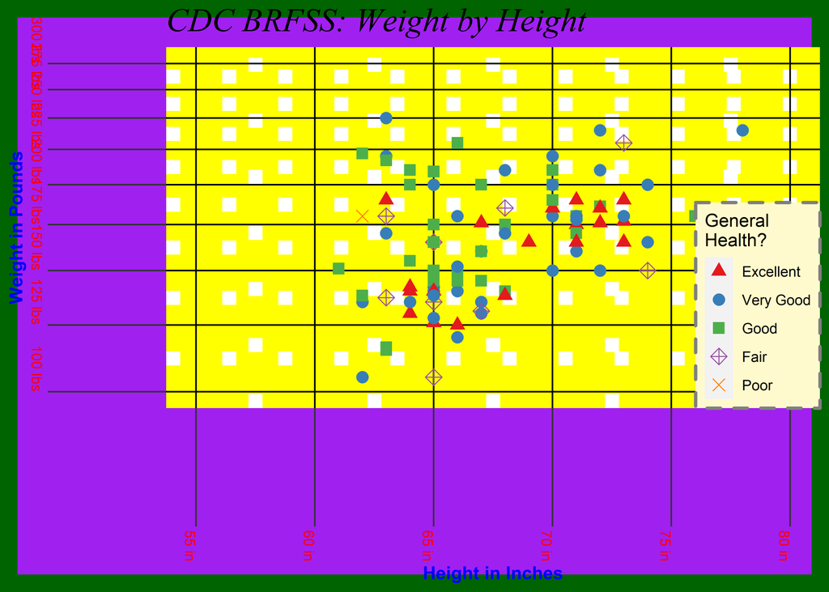

```r
base +
    theme(
      legend.position = c(1, 0)
    , legend.justification = c(1, 0)
    , axis.title = element_text(color="blue", face = "bold")
    , axis.text = element_text(color = "red", angle = -90)
    , axis.ticks.length = unit(1, "in")
    , panel.grid.major = element_line(color = "black", size = .5)
    , panel.grid.minor = element_line(color="white", size = 4, linetype="dotted")
    , panel.background = element_rect(fill="yellow")
    , plot.background = element_rect(color="darkgreen", fill="purple", size = 10)
    , plot.subtitle = element_text(size = 20, family="serif", face="italic")
    , legend.background = element_rect(fill="lemonchiffon", color="grey50", size = 1, linetype="dashed")
  )
```

### Exercise 3

Using data from `cdc_small` create a few (at least two) graphics (maybe one scatterplot and one barplot). Style the plots so they follow a “Northwestern” theme. Check out the following webpages to help create the theme:

[Visual Identity](https://www.northwestern.edu/brand/visual-identity/index.html)

- [Web Colors](https://www.northwestern.edu/brand/visual-identity/color/digital-colors.html)
- [Secondary Palette](https://www.northwestern.edu/brand/visual-identity/color/secondary-palette.html)
- [Fonts & Typography](https://www.northwestern.edu/brand/visual-identity/fonts-typography/index.html) — Need to use [substitute fonts](https://www.northwestern.edu/brand/visual-identity/fonts-typography/substitute-fonts.html)

```r
NW_purple   <- "#4E2A84"
NW_purple30 <- "#B6ACD1"
NW_black80  <- "#342F2E"
NW_black50  <- "#716C6B"
NW_black20  <- "#BBB8B8"
NW_black10  <- "#D8D6D6"
```

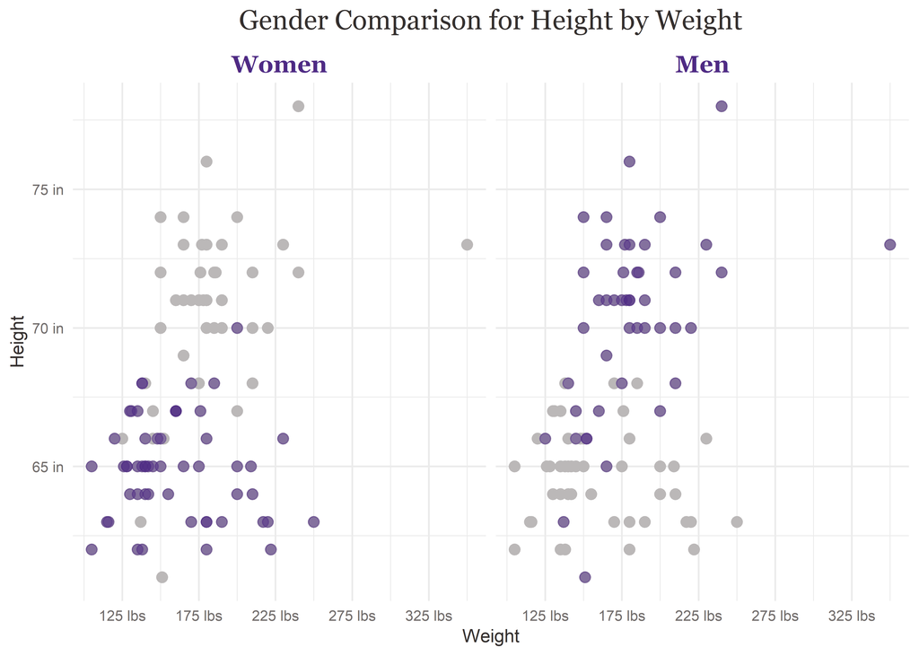

```r
ggplot(cdc_small, aes(weight, height)) +
  geom_point(
      data = select(cdc_small, -gender)
    , color = NW_black20
    , size = 2.5
  ) +
  geom_point(
      color = NW_purple
    , alpha = 0.5
    , size = 2.5
    , show.legend = FALSE
  ) +
  scale_x_continuous(
      labels = scales::unit_format(unit = "lbs")
    , breaks = seq(125, 325, 50)
  ) +
  scale_y_continuous(labels = scales::unit_format(unit = "in", accuracy = 1))+
  facet_wrap(~ factor(gender, labels = c("Women", "Men"))) +
  xlab("Weight") +
  ylab( "Height") +
  theme_minimal() +
  ggtitle("Gender Comparison for Height by Weight")+
  theme(
      plot.title = element_text(family = "Georgia", color = NW_black80, hjust = 0.5
                                , size = 15
                                )
    , strip.text.x = element_text(family ="Georgia", face = "bold", color = NW_purple, size=13)
    , axis.title = element_text(color = NW_black80, size=10)
    , axis.text = element_text(color = NW_black50, size = 8)
  )
```

```r
cdc_small_adj <- cdc_small %>%
  mutate(exercise = factor(exerany, labels=c("No", "Yes")))

labels <- cdc_small_adj %>%
  group_by(gender, genhlth) %>%
  summarize(count = paste("n =", n()))
```

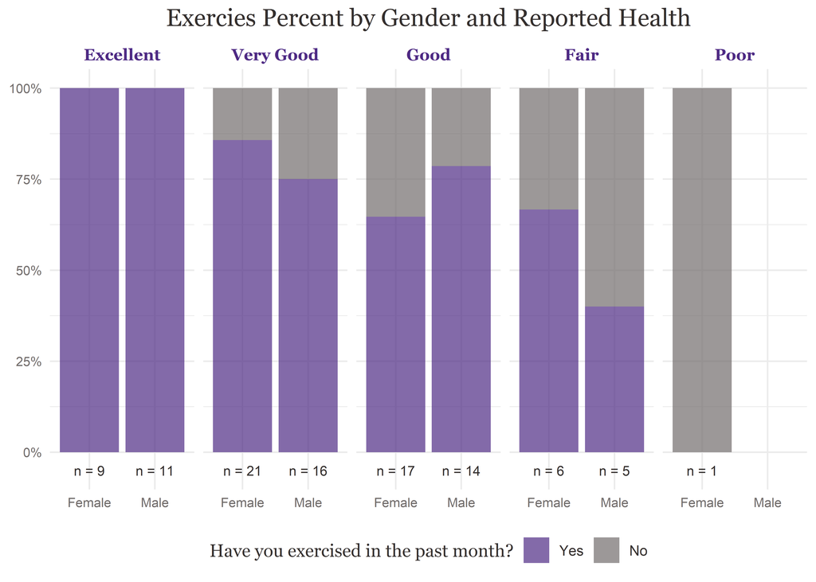

```r
ggplot(cdc_small_adj, aes(gender))+
  geom_bar(
      aes(fill = exercise)
    , position = "fill"
    , alpha = 0.7
  )+
  facet_wrap(~genhlth, nrow=1) +
  scale_x_discrete(
      name = NULL
    , labels = c("Female", "Male")
  )+
  scale_y_continuous(
      name = NULL
    , labels = scales::percent_format()
  ) +
  scale_fill_manual(
      name = "Have you exercised in the past month?"
    , labels = c("No", "Yes")
    , values = c(NW_black50, NW_purple)
    , guide = guide_legend(reverse = TRUE)
  ) +
  geom_text(
      data = labels
    , aes(label = count, y = -0.05)
    , size = 3
    , color = NW_black80
  ) +
  ggtitle("Exercies Percent by Gender and Reported Health") +
  theme_minimal() +
  theme(
      plot.title = element_text(family = "Georgia", color = NW_black80, hjust = 0.5
                                , size = 15
                                )
    , strip.text.x = element_text(family ="Georgia", face = "bold", color = NW_purple, size=10)
    , axis.title = element_text(color = NW_black80, size=10)
    , axis.text = element_text(color = NW_black50, size = 8)
    , legend.position =  "bottom"
    , legend.text = element_text(color = NW_black80)
    , legend.title =element_text(family = "Georgia", color = NW_black80)
  )
```